# Qualitative Prediction of Weight Lifting Exercise

Paul Smith

20 September 2015

### Background

Physical exercise is generally measured in quantative terms such as distance ran, repetitions performed or count of steps. However the quality of exercise i.e. how well it was performed is more subjective and therefore usually not measured. With the advent of personal body sensor devices such as Fitbit or Nike Fuel/Band it is now easy to collect biomechanical movement data that can be used to assess how well an exercise is being performed.

### Objective

In this study of supervised machine learning we are attempting to classify how well a bicep curl was performed based on biomechanical data collected from body sensors. This could be used to help someone train more effectively and reduce injury.

### Approach

Weight lifting data from the Human Activity Recognition study was used to train a model with the “random forest” multi-class classification algorithm. The source data sets were;

`Training`: https://d396qusza40orc.cloudfront.net/predmachlearn/pml-training.csv

`Test`: https://d396qusza40orc.cloudfront.net/predmachlearn/pml-testing.csv

The training data was split 60/40 to enable cross-validation and assess the out-of-sample error rate. This model was then used to classify how well a bicep curl was performed from a data-set of 20 test observations into one of 5 categories.

The Random Forest algorithm is a decision tree algorithm that works by repeatedly subdividing the feature space to determine the best classifiers. This algorithm was chosen as it is a well-known multi-class classifier with a low memory footprint and good accuracy.

*R version 3.2.2 (2015-08-14)*

### Data Description

- The training data set has `19622` observations by `160` variables.
- `67` variables contain missing values. These variables only have values for a small fraction of the total observations.
- `37` variables are of class “factor”. These variables only have values for a small fraction of the total observations.
- The *outcome* variable for prediction is given as `"classe"` in column 160 in the training data set.
- The test data set comprises `20` observations by `160` variables.

#### Training Data

```r
dataTrain<-read.csv('Coursera/Machine Learning/pml-training.csv')
dim(dataTrain)
```

```
## [1] 19622   160
```

```r
# find the column number of the outcome variable
grep("classe",colnames(dataTrain))
```

```
## [1] 160
```

```r
# show the categories of the outcome variable
levels(dataTrain$classe)
```

```
## [1] "A" "B" "C" "D" "E"
```

```r
# show all variables that include missing values - result = 67
m<-sapply(dataTrain,function(x) sum(is.na(x)));m[m>0];length(m[m>0])
# show all variables that are non-numeric - result = 37
n<-sapply(dataTrain,function(x) class(x));n[n=="factor"];length(n[n=="factor"])
```

#### Test Data

```r
dataTest<-read.csv('Coursera/Machine Learning/pml-testing.csv')
dim(dataTest)
```

```
## [1]  20 160
```

```r
colnames(dataTest)[160]
```

```
## [1] "problem_id"
```

### Training Data Preparation

The aim of the data preparation was to exclude variables from the training data set that had little or no predictive value. There were five types of these variables identified;

- Variables that did not pertain to the accelerometer data and had `no obvious predictive value` (columns 1:7) e.g. person’s name.
- Variables containing `missing values` - these were not imputed due to the significant number of observations with these values.
- Variables of class `'factor'`. Some variables were factorised as they included NULL string values - these were not imputed due to the significant number of observations with these values.
- Variables that had `'near zero variability'`.
- Variables that were `highly correlated` to other variables and therefore redundant.

The following steps were taken to remove these variables;

- *Step 1* - removed `7` variables that had no obvious predictive value; serial counter, user_name, raw_timestamp_part_1, raw_timestamp_part_2, cvtd_timestamp, new_window, num_window.
- *Step 2* - removed `67` variables that contained NA values.
- *Step 3* - removed `33` variables that were of class ‘factor’ (excluding “classe”).
- *Step 4* - check for any variables that have a ‘near zero variability’; `none identified.`
- *Step 5* - removed `7` variable that had a high correlation >0.9

> The final feature set for training the model comprised 45 variables

```r
# step 1
d1<-dataTrain[8:160]

# step 2 - remove NA columns
m<-sapply(d1,function(x) sum(is.na(x)))
d2<-d1[names(m[m==0])]

# step 3 - remove factor columns
n<-sapply(d2,function(x) class(x))
d3<-d2[names(n[!n=="factor"])]
d3<-cbind(d3,d2[86])
```

```r
# step 4 - check for variables with near zero variability (nza)
nearZeroVar(d3,saveMetrics=TRUE)
# no variables found with nza
# example output (actual console output too large):
##                      freqRatio percentUnique zeroVar   nzv
## roll_belt             1.101904     6.7781062   FALSE FALSE
## pitch_belt            1.036082     9.3772296   FALSE FALSE
```

```r
# step5 - remove variables that have a high correlation with each other
d4<-d3[,-findCorrelation(abs(cor(d3[,-53])),cutoff=0.90)]
```

##### Scaled Correlation of Final Feature Set

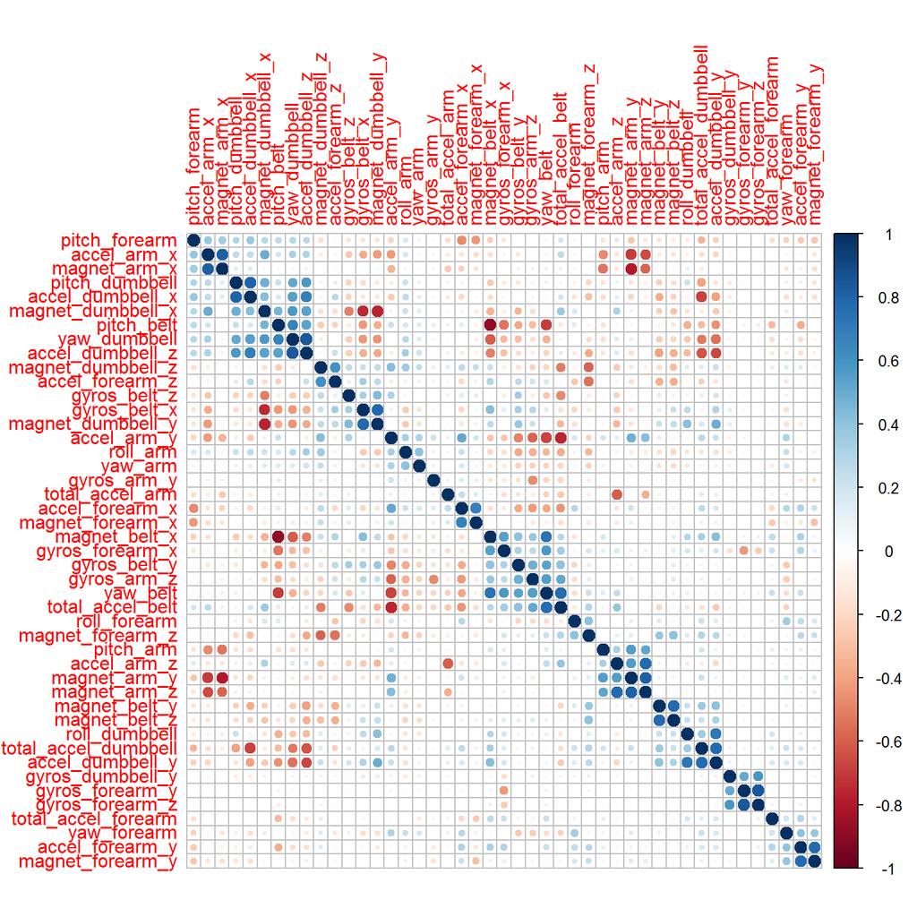

```r
# plot final feature selection as scaled correlation matrix
d4.scale<-scale(d4[1:45],center=TRUE,scale=TRUE);
cor.d4<-cor(d4.scale)
corrplot(cor.d4, order = "hclust")
```

#### Sub-Set the Training Data for *Cross Validation*

The processed training data was partitioned into two subsets; training 60% `(11776)` and validation 40% `(7846)`. The validation set would provide an estimated *out of sample* error that could be expected when the model was applied to the ‘independent’ test data.

```r
set.seed(2015)
inTrain<-createDataPartition(y=d4$classe,p=0.6,list=FALSE)
training<-d4[inTrain,]
validation<-d4[-inTrain,]
```

### Model Fitting

The Random Forest model was used for prediction based on the *randomForest* package. The ‘*tunRF*’ was used to find the best ‘*mtry*’ value of `9` and ‘*ntree*’ value was set to an odd number to break any voting ties.

> The OOB estimated error rate of the model was calculated as `0.61%`.  
> Based on *cross vaildation* we can expect an *out of sample* error rate of `0.73%`.

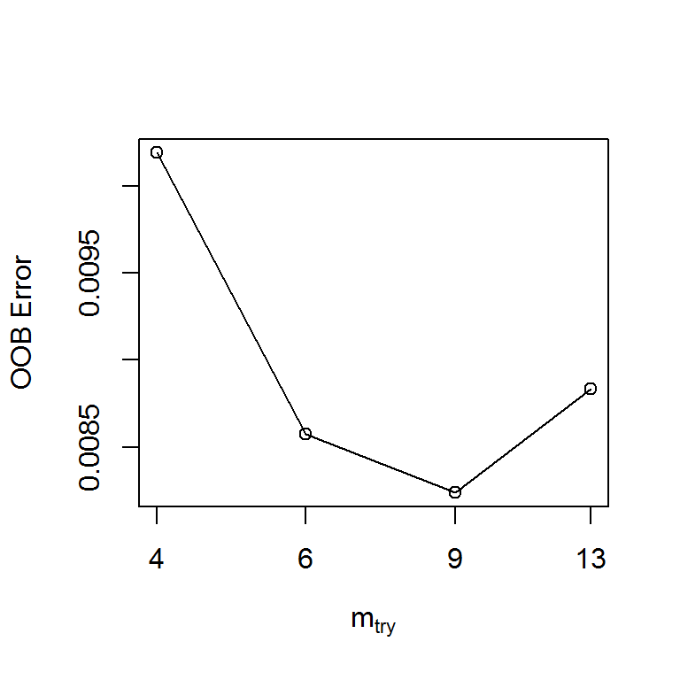

```r
# finding the best value to use for 'mtry' parameter in the 'Random Forest'
set.seed(2015)
bestmtry<-tuneRF(training[-46],training$classe,ntreeTry=100,
     stepFactor=1.5,improve=0.01,trace=FALSE,plot=TRUE,dobest=FALSE)
```

```r
# fit the model to the training data or model from file if available to save recalculating
if(file.exists("RFobj.RData")){
    load("RFobj.RData")
} else {
    set.seed(2015)
    fitRF<-randomForest(classe~.,data=training,mtry=9,ntree=1501,
                        keep.forest=TRUE,importance=TRUE, proximity=TRUE)
    save(fitRF,file='RFobj.RData')
}
# check the estimated "OOB" error rate
print(fitRF)
```

```
##
## Call:
##  randomForest(formula = classe ~ ., data = training, mtry = 9,      ntree = 1501, keep.forest = TRUE, importance = TRUE, proximity = TRUE)
##                Type of random forest: classification
##                      Number of trees: 1501
## No. of variables tried at each split: 9
##
##         OOB estimate of  error rate: 0.61%
## Confusion matrix:
##      A    B    C    D    E  class.error
## A 3346    2    0    0    0 0.0005973716
## B   11 2258   10    0    0 0.0092145678
## C    0   17 2034    2    1 0.0097370983
## D    0    0   22 1907    1 0.0119170984
## E    0    0    2    4 2159 0.0027713626
```

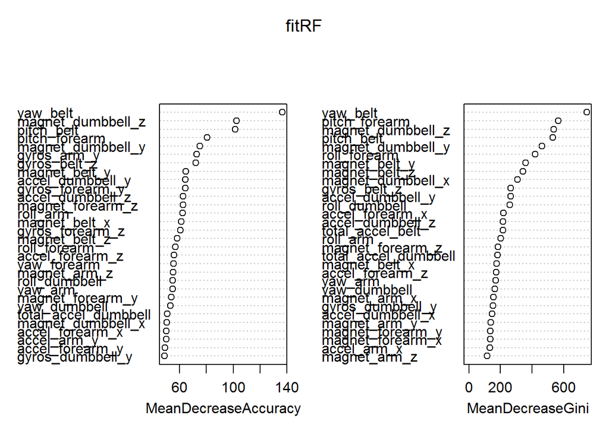

```r
# plot of variables by importance from the model
varImpPlot(fitRF)
```

#### Cross Validation

The trained model was next applied to the validation set to calculate the `out of sample` error rate.

```r
Predict<-predict(fitRF, validation)
# determine the out of sample error usinf the validation data sub-set
confusionMatrix(Predict, validation$classe)
```

```
## Confusion Matrix and Statistics
##
##           Reference
## Prediction    A    B    C    D    E
##          A 2228   13    0    0    0
##          B    1 1498    9    0    0
##          C    2    7 1356   12    4
##          D    0    0    3 1274    5
##          E    1    0    0    0 1433
##
## Overall Statistics
##
##                Accuracy : 0.9927
##                  95% CI : (0.9906, 0.9945)
##     No Information Rate : 0.2845
##     P-Value [Acc > NIR] : < 2.2e-16
##
##                   Kappa : 0.9908
##  Mcnemar's Test P-Value : NA
##
## Statistics by Class:
##
##                      Class: A Class: B Class: C Class: D Class: E
## Sensitivity            0.9982   0.9868   0.9912   0.9907   0.9938
## Specificity            0.9977   0.9984   0.9961   0.9988   0.9998
## Pos Pred Value         0.9942   0.9934   0.9819   0.9938   0.9993
## Neg Pred Value         0.9993   0.9968   0.9981   0.9982   0.9986
## Prevalence             0.2845   0.1935   0.1744   0.1639   0.1838
## Detection Rate         0.2840   0.1909   0.1728   0.1624   0.1826
## Detection Prevalence   0.2856   0.1922   0.1760   0.1634   0.1828
## Balanced Accuracy      0.9979   0.9926   0.9937   0.9947   0.9968
```

### Predicting the Test Data Set using the Fitted Model

Once the test data set has been prepared as per the training data set, the fitted model was applied and the predictions displayed.

```r
# remove variables from Test data set that were removed from training data aset
cols<-names(training)
t1 <- dataTest[, names(dataTest) %in% cols]
t2<-cbind(t1[],dataTest[160])

# apply prediction model to test data set
Final <- predict(fitRF, t2)

# display results of test case predictions
Final
```

```
##  1  2  3  4  5  6  7  8  9 10 11 12 13 14 15 16 17 18 19 20
##  B  A  B  A  A  E  D  B  A  A  B  C  B  A  E  E  A  B  B  B
## Levels: A B C D E
```

### References

Qualitative Activity Recognition of Weight Lifting Exercises Velloso, E.; Bulling, A.; Gellersen, H.; Ugulino, W.; Fuks, H. Qualitative Activity Recognition of Weight Lifting Exercises. Proceedings of 4th International Conference in Cooperation with SIGCHI (Augmented Human ’13) . Stuttgart, Germany: ACM SIGCHI, 2013.  
URL: http://groupware.les.inf.puc-rio.br/public/papers/2013.Velloso.QAR-WLE.pdf  
http://groupware.les.inf.puc-rio.br/har

Coursera MOOC - Practical Machine Learning, Jeff Leek, PhD, Roger D. Peng, PhD, Brian Caffo, PhD. URL: https://class.coursera.org/predmachlearn-032/wiki/syllabus

randomForest: Breiman and Cutler’s random forests for classification and regression randomForest package R port by Andy Liaw and Matthew Wiener https://cran.r-project.org/web/packages/randomForest/index.html